# RNA-Seq Analysis SRP022028 Revision

Trent Gutierrez

2022-09-27

## Introduction

### Research question

This RNA-Seq analysis looks at data from iPSCs derived from patients of 22q11.2 deletion syndrome and how it affects neuronal development and activity pathways. 22q11.2 DS is one of the highest known risk factors for developing schizophrenia (SZ) and research has been limited due to the fact that analyzing developing human brains is inaccessible, that’s where Induced Pluripotent Stem Cells (iPSC) come in, they help give researchers a opportunity to grow patient-specific neurons in vitro, and these cells can have the abnormalities needed for the investigation. The data for this analysis will be 8 samples of 14 day old neurons, where 4 are from SZ patients (2 confirmed 22q11.2 DS samples, 2 uncertain patient samples) and 4 controls of normal neurons.

### Data Input

This is the metadata for our RNA-Seq analysis, the rest of the analysis will use this data to identify what each sample is.

```r
metadata %>%
  as.data.frame() %>%
  dplyr::select(genotype,conditions) %>%
  kbl(caption = "Metadata for SRP022028") %>%
  kable_styling(bootstrap_options = "striped", full_width = T, html_font = "Cambria")
```

Metadata for SRP022028

|  | genotype | conditions |
| --- | --- | --- |
| SRR836527 | WT | sample group: patients |
| SRR836528 | 22q11Del | sample group: patients |
| SRR836529 | WT | sample group: patients |
| SRR836530 | 22q11Del | sample group: patients |
| SRR836531 | WT | sample group: contol |
| SRR836532 | WT | sample group: contol |
| SRR836533 | WT | sample group: contol |
| SRR836534 | WT | sample group: contol |

## Results

### PCA Plot

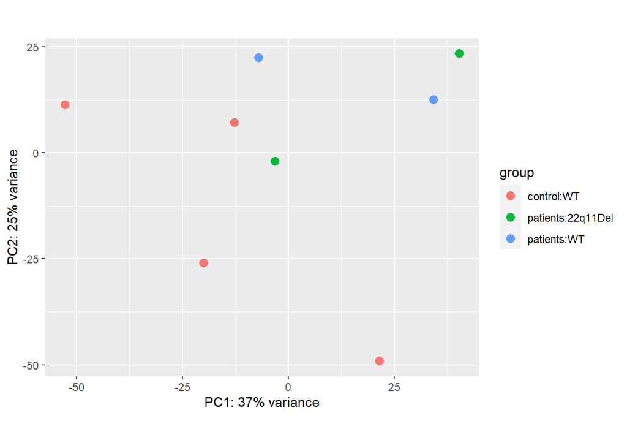

```r
vsd_dds <- vst(dds)

plotPCA(vsd_dds, intgroup = c("condition","genotype"))
```

### Significant DEGs table

```r
datatable(sigresults_dataframe_symbols_merge, class = 'cell-border stripe' ,
          caption = "Table 1: Patient vs Control Significant Genes")
```

|  | gene_symbol | ID | log2FoldChange | stat | pvalue | padj |
| --- | --- | --- | --- | --- | --- | --- |
| 1 | GRM7-AS3 | ENSG00000226258 | 26.6431195015262 | 7.87462904694295 | 3.41755303789037e-15 | 1.75311926961181e-11 |
| 2 |  | ENSG00000223719 | 24.7580468679807 | 7.54175759653363 | 4.63679056025067e-14 | 1.21787736445389e-10 |
| 3 | KRT8P21 | ENSG00000229636 | 24.3213929337685 | 7.53827879583082 | 4.76214917175388e-14 | 1.21787736445389e-10 |
| 4 | LINC01297 | ENSG00000274827 | 25.002650903503 | 7.38956268131569 | 1.47312510561274e-13 | 1.51135270210339e-10 |
| 5 | LINC02565 | ENSG00000267726 | 24.5425432177792 | 7.25345879357299 | 4.06261016661938e-13 | 2.31114473064648e-10 |
| 6 | KRTAP19-1 | ENSG00000184351 | 24.4421900378586 | 7.22377076854879 | 5.05654672710507e-13 | 2.56185882206096e-10 |
| 7 | DUXAP6 | ENSG00000258726 | 24.1746391576556 | 7.14468054474466 | 9.02054245562621e-13 | 3.13803825349933e-10 |
| 8 | ZG16B | ENSG00000162078 | 24.1400924163183 | 7.13437998438605 | 9.72244029716192e-13 | 3.32491254095776e-10 |
| 9 | GSTA3 | ENSG00000174156 | 23.956077291791 | 7.07991950771606 | 1.44238216317539e-12 | 4.35139365269076e-10 |
| 10 |  | ENSG00000259761 | 23.9522756300181 | 7.07879686955881 | 1.4541134290447e-12 | 4.35139365269076e-10 |

[output cut: 689 more lines]

### Enhanced Volcano plot

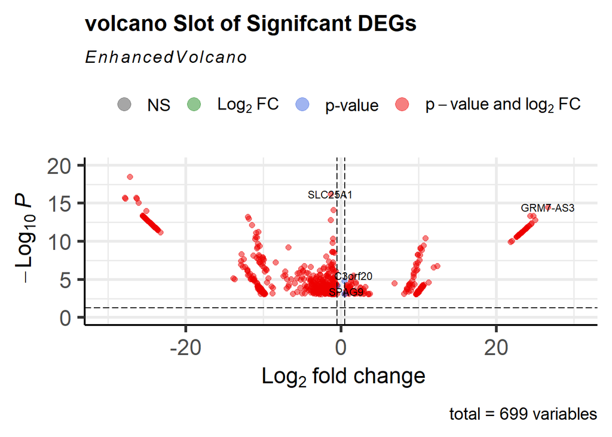

```r
EnhancedVolcano(sigresults_dataframe_symbols_merge,
                lab = sigresults_dataframe_symbols_merge$gene_symbol,
                x = 'log2FoldChange',
                y = 'pvalue',
                title ="volcano Slot of Signifcant DEGs",
                xlim = c(-30,30),
                ylim = c(0,20),
                pCutoff = 0.05,
                FCcutoff = 0.5,
                pointSize = 2.0,
                labSize = 3.0 )
```

### Heatmap

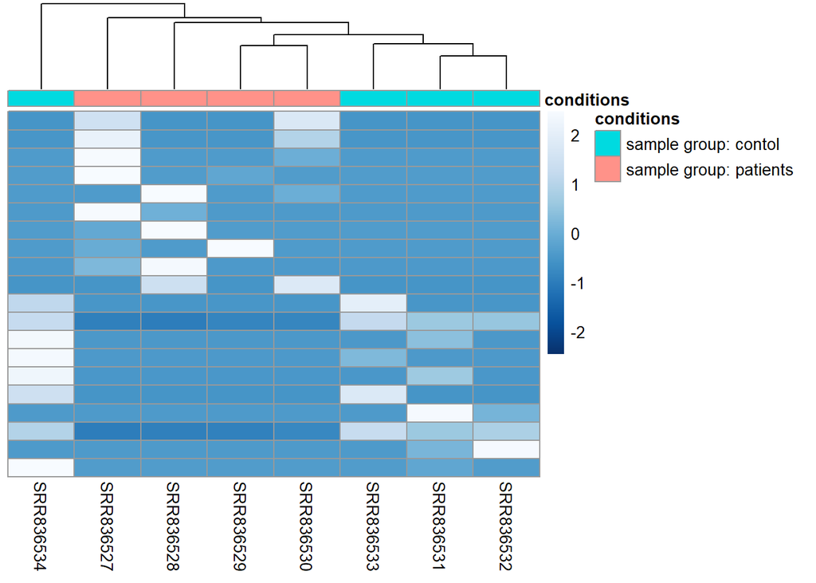

```r
heatmap <- pheatmap(sig_norm_dds_counts,
                    color = colors,
                    cluster_rows = FALSE,
                    show_rownames = FALSE,
                    annotation = dplyr::select(heatmeta,conditions),
                    scale = "row")
```

NOTE: I think a heatmap like this would be better used at the beginning of the paper, it looks like exploratory data.

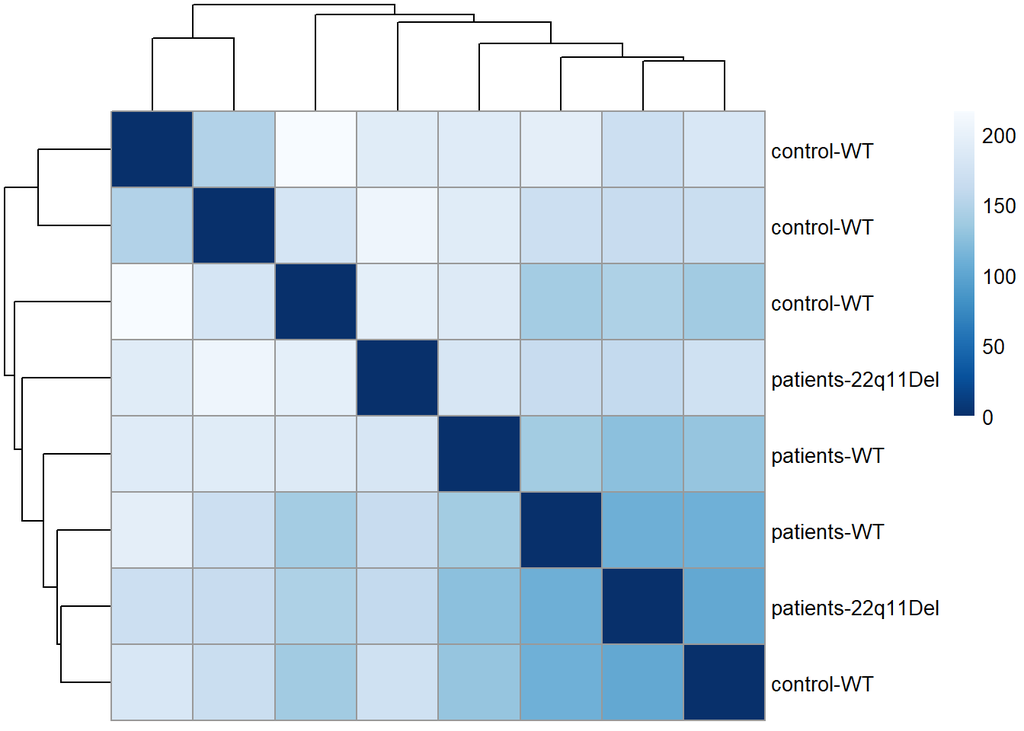

```r
distheatmap <- pheatmap(sampledistmatrix,
                        clustering_distance_rows=sampledist,
                        clustering_distance_cols=sampledist,
                        col=colors)
```

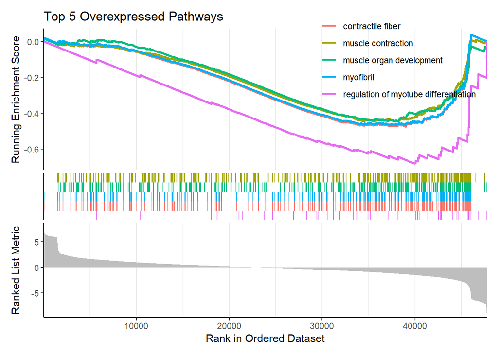

```r
overGSEAplot <- gse %>%
  arrange(rank) %>%
  gseaplot2(geneSetID = 1:5, title = "Top 5 Overexpressed Pathways")
overGSEAplot
```

#### Top 5 Underexpressed

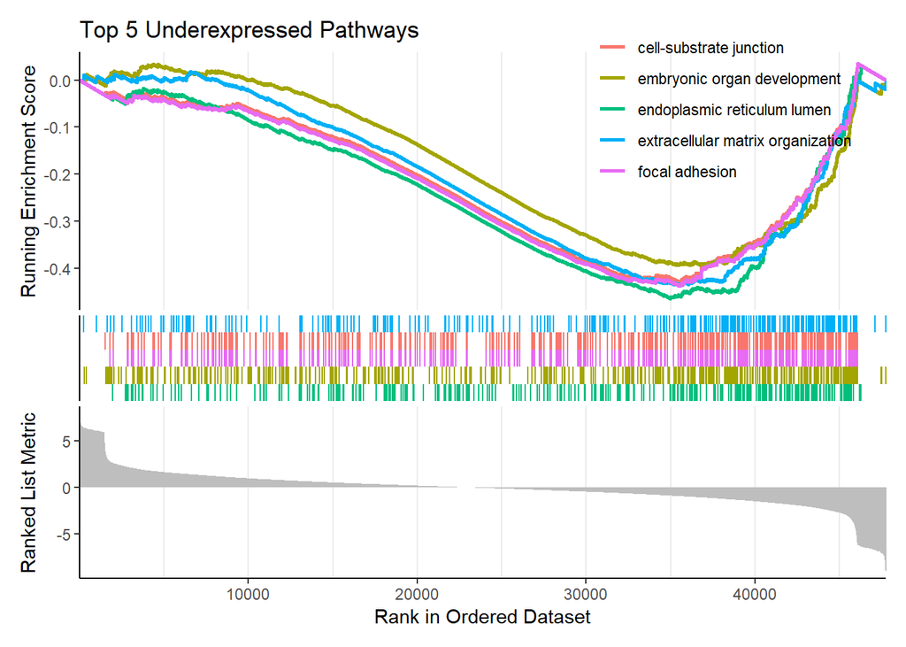

```r
underGSEAplot <- gse %>%
  arrange(desc(rank)) %>%
  gseaplot2(geneSetID = 1:5, title = "Top 5 Underexpressed Pathways")
underGSEAplot
```